# Practicum Activity: EDA and Predictive Modeling on the Pima Indians Diabetes Dataset

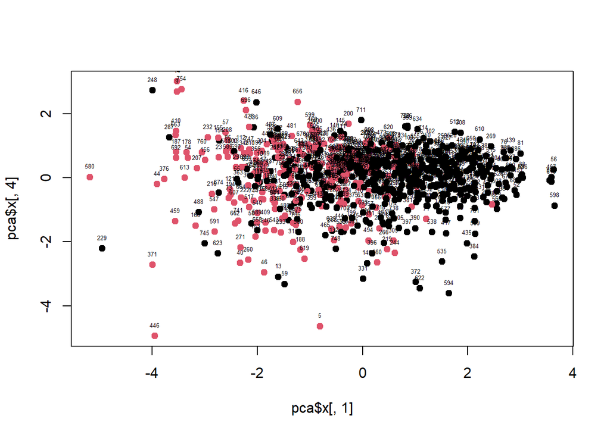

```r
#PC1 vs. PC4
plot(pca$x[,1], pca$x[,4], col = as.factor(diabetes_clean$Outcome), pch=19)
text(x=pca$x[,1], y=pca$x[,4], labels= rownames(diabetes_clean[,-9]), cex = 0.4, pos =3)
```

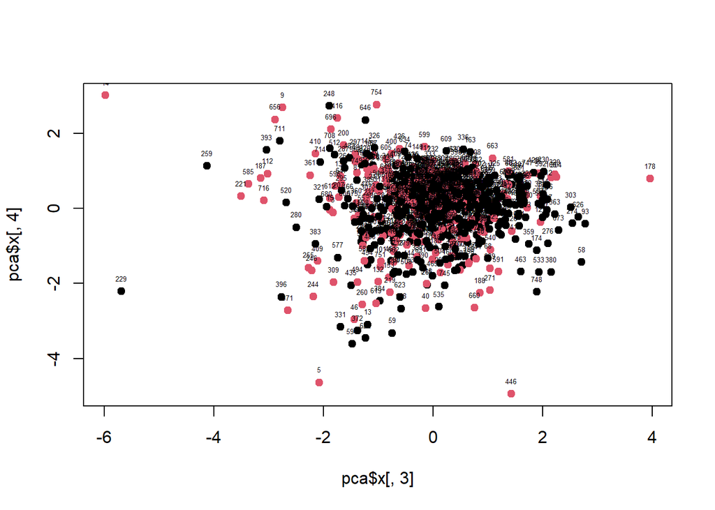

```r
#PC3 vs. PC4
plot(pca$x[,3], pca$x[,4], col = as.factor(diabetes_clean$Outcome), pch=19)
text(x=pca$x[,3], y=pca$x[,4], labels= rownames(diabetes_clean[,-9]), cex = 0.4, pos =3)
```

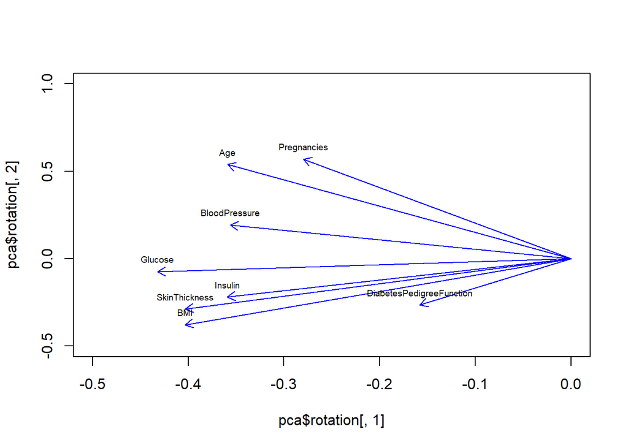

```r
#The score plots from above show us every sample distinguished of each one by their color. In the PC1 vs. PC2 we can see a tendency of the diabetics going left and the non ones to the right and the same in PC1 vs. PC3, P1 vs. PC4. But we can't see a clear separation for the others score plots.Moreover, we can't make a conclusion because in PC1 vs. PC2 we are only explaining a variance about 50%.

#PC1 and PC2 loading plot

plot(pca$rotation[,1], pca$rotation[,2], type ="n", xlim=c(-0.5, 0), ylim=c(-0.5, 1))
arrows(x0 = 0, y0 = 0, pca$rotation[,1], pca$rotation[,2], length = 0.1, col = "blue")
text(x=pca$rotation[,1], y=pca$rotation[,2], labels= colnames(diabetes_clean[,-9]), cex = 0.6, pos =3)
```

```r
#The Loading plot show us which variable influences the most in our analysis in PC1 vs PC2 is the age.
```

# 5 Part 4: Feature Engineering (Optional but Recommended)

```r
# TODO: Example — create BMI categories per WHO standards
diabetes_clean <- diabetes_clean |>
  mutate(BMI_category = case_when(
    BMI < 18.5 ~ "Underweight",
    BMI < 25 ~ "Normal",
    BMI < 30 ~ "Overweight",
    TRUE ~ "Obese"
  ))
```

Justify why this feature might improve model performance or interpretability.

> *Doing this procedure, lets us know without thinking every time if a patient has high or low BMI. With this gives us another variable that gives us more information about if it is correlated.*

# 6 Part 5: Predictive Modeling

```r
set.seed(123)
diabetes_clean <- diabetes_clean |> mutate(Outcome = factor(Outcome, labels = c("No", "Yes")))

train_index <- createDataPartition(diabetes_clean$Outcome, p = 0.8, list = FALSE)
train_data <- diabetes_clean[train_index, ]
test_data <- diabetes_clean[-train_index, ]
```

## 6.1 Model 1: Logistic Regression (baseline)

```r
log_model <- train(
  Outcome ~ . - BMI_category, # TODO: adjust formula if you engineered features
  data = train_data,
  method = "glm",
  family = "binomial",
  preProcess = c("center", "scale")
)

log_preds <- predict(log_model, test_data)
log_probs <- predict(log_model, test_data, type = "prob")[, "Yes"]

confusionMatrix(log_preds, test_data$Outcome, positive = "Yes")
```

```
## Confusion Matrix and Statistics
##
##           Reference
## Prediction No Yes
##        No  90  18
##        Yes 10  35
##
##                Accuracy : 0.817
##                  95% CI : (0.7465, 0.8748)
##     No Information Rate : 0.6536
##     P-Value [Acc > NIR] : 6.204e-06
##
##                   Kappa : 0.581
##
##  Mcnemar's Test P-Value : 0.1859
##
##             Sensitivity : 0.6604
##             Specificity : 0.9000
##          Pos Pred Value : 0.7778
##          Neg Pred Value : 0.8333
##              Prevalence : 0.3464
##          Detection Rate : 0.2288
##    Detection Prevalence : 0.2941
##       Balanced Accuracy : 0.7802
##
##        'Positive' Class : Yes
##
```

## 6.2 Model 2: Random Forest

```r
rf_model <- train(
  Outcome ~ . - BMI_category,
  data = train_data,
  method = "rf",
  preProcess = c("center", "scale")
)

rf_preds <- predict(rf_model, test_data)
rf_probs <- predict(rf_model, test_data, type = "prob")[, "Yes"]

confusionMatrix(rf_preds, test_data$Outcome, positive = "Yes")
```

```
## Confusion Matrix and Statistics
##
##           Reference
## Prediction No Yes
##        No  93   6
##        Yes  7  47
##
##                Accuracy : 0.915
##                  95% CI : (0.8591, 0.954)
##     No Information Rate : 0.6536
##     P-Value [Acc > NIR] : 4.152e-14
##
##                   Kappa : 0.8132
##
##  Mcnemar's Test P-Value : 1
##
##             Sensitivity : 0.8868
##             Specificity : 0.9300
##          Pos Pred Value : 0.8704
##          Neg Pred Value : 0.9394
##              Prevalence : 0.3464
##          Detection Rate : 0.3072
##    Detection Prevalence : 0.3529
##       Balanced Accuracy : 0.9084
##
##        'Positive' Class : Yes
##
```

## 6.3 Model 3: PLS-DA analysis ( LVs plot + VIP)

```r
plsda_model <- train(
  Outcome ~ . - BMI_category,
  data = train_data,
  method = "pls",
  preProcess = c("center", "scale")
)

plsda_preds <- predict(plsda_model, test_data)
plsda_probs <- predict(plsda_model, test_data, type = "prob")[, "Yes"]

confusionMatrix(plsda_preds, test_data$Outcome, positive = "Yes")
```

```
## Confusion Matrix and Statistics
##
##           Reference
## Prediction No Yes
##        No  91  19
##        Yes  9  34
##
##                Accuracy : 0.817
##                  95% CI : (0.7465, 0.8748)
##     No Information Rate : 0.6536
##     P-Value [Acc > NIR] : 6.204e-06
##
##                   Kappa : 0.5771
##
##  Mcnemar's Test P-Value : 0.08897
##
##             Sensitivity : 0.6415
##             Specificity : 0.9100
##          Pos Pred Value : 0.7907
##          Neg Pred Value : 0.8273
##              Prevalence : 0.3464
##          Detection Rate : 0.2222
##    Detection Prevalence : 0.2810
##       Balanced Accuracy : 0.7758
##
##        'Positive' Class : Yes
##
```

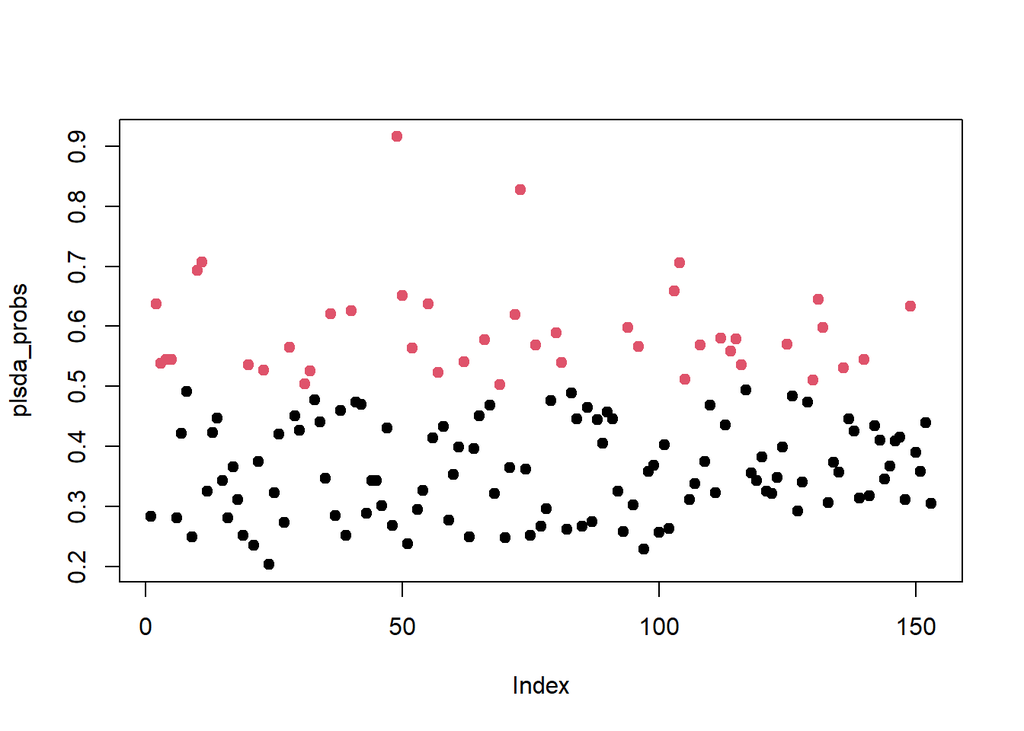

```r
plot(plsda_probs,col = as.factor(plsda_preds), pch=19)
```

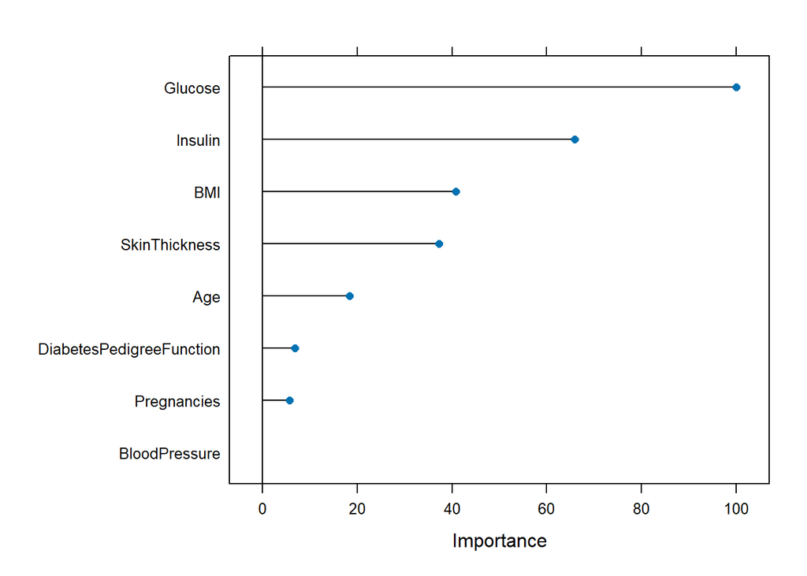

```r
plot(varImp(plsda_model))
```

## 6.4 ROC Curves

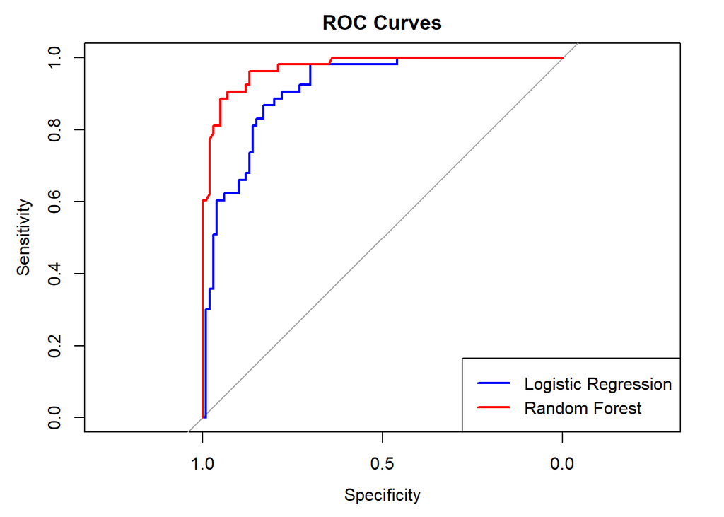

```r
roc_log <- roc(test_data$Outcome, log_probs, levels = c("No", "Yes"))
roc_rf <- roc(test_data$Outcome, rf_probs, levels = c("No", "Yes"))

plot(roc_log, col = "blue", main = "ROC Curves")
lines(roc_rf, col = "red")
legend("bottomright", legend = c("Logistic Regression", "Random Forest"),
       col = c("blue", "red"), lwd = 2)
```

```r
# AUC values
auc(roc_log)
```

```
## Area under the curve: 0.913
```

```r
auc(roc_rf)
```

```
## Area under the curve: 0.9727
```

**Reflection question:** Compare the two models. Which performs better, and on which metric? Why might accuracy alone be misleading given the class imbalance?

> *The one that performs better is the randomforest according to the metric AUC (area under the ROC curve). Accuracy alone can be misleading because if one group is a lot bigger than the other, a model can achieve high accuracy by simply predicting the major group.*

**Reflection question:** In a medical screening context, would you prioritize precision or recall for the “diabetes” class? Explain your reasoning.

> *We would prioritize recall, because in a medical context is best to diagnose every true positive case, prioritizing precision could lead to missing diabetic persons who need treatment, delaying this treatment and leading to more serious problems.*

# 7 Part 6: Interpretation and Communication

```r
summary(log_model$finalModel)
```

```
##
## Call:
## NULL
##
## Coefficients:
##                          Estimate Std. Error z value Pr(>|z|)
## (Intercept)              -0.84760    0.10915  -7.765 8.13e-15 ***
## Pregnancies               0.31618    0.12094   2.614 0.008938 **
## Glucose                   0.90234    0.13183   6.845 7.67e-12 ***
## BloodPressure            -0.05153    0.11709  -0.440 0.659876
## SkinThickness             0.32181    0.13814   2.330 0.019825 *
## Insulin                   0.51762    0.14933   3.466 0.000528 ***
## BMI                       0.34713    0.13628   2.547 0.010858 *
## DiabetesPedigreeFunction  0.25309    0.10632   2.380 0.017293 *
## Age                       0.13862    0.12589   1.101 0.270855
## ---
## Signif. codes:  0 '***' 0.001 '**' 0.01 '*' 0.05 '.' 0.1 ' ' 1
##
## (Dispersion parameter for binomial family taken to be 1)
##
##     Null deviance: 796.05  on 614  degrees of freedom
## Residual deviance: 566.50  on 606  degrees of freedom
## AIC: 584.5
##
## Number of Fisher Scoring iterations: 5
```

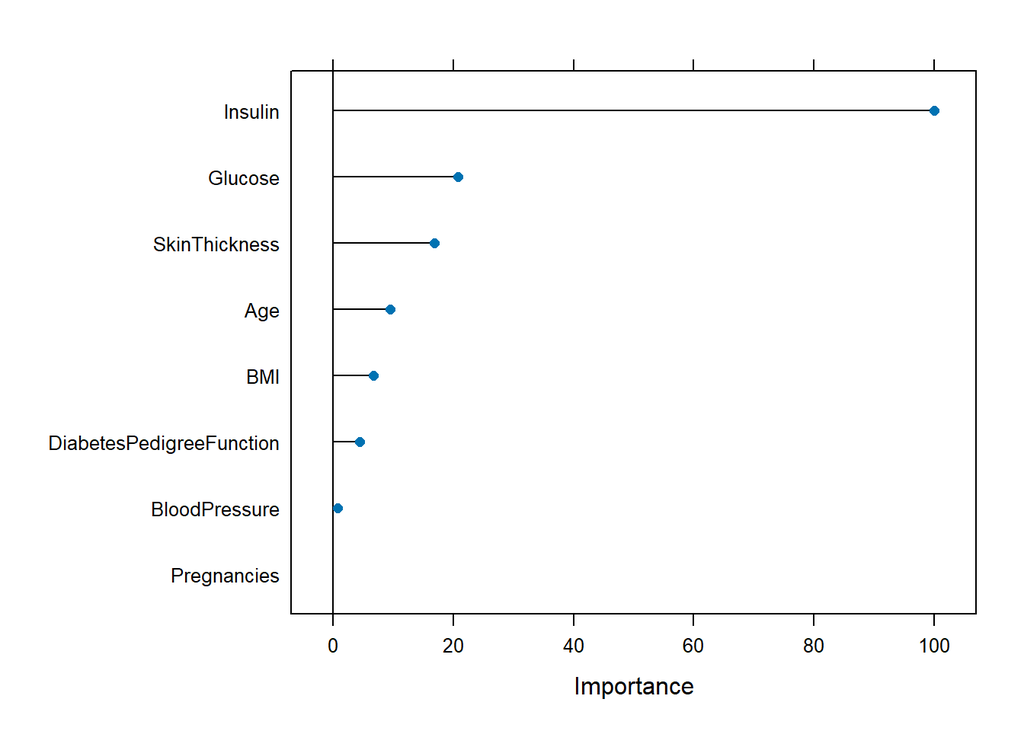

```r
varImp(rf_model) |> plot()
```

Write a short summary (1–2 paragraphs) explaining your findings to a non-technical audience (e.g., a clinic administrator).

> *We can make models of prediction for diseases like diabetes analyzing some characteristics of the subjects that we are studying. The model will be more influenced by some of this characteristics than the others and it will be more complete if we measure more characteristics and more people, also we have to control different aspects of the lives of our subjects like ethnics or environment if we want to apply the model to a certain group.*

# 8 Part 7: Critical Reflection and Ethics

1. This dataset only includes female patients of Pima Indian heritage. What are the limitations of generalizing a model trained on this data to other populations?

> *The limitations of this study are that we can’t apply the model to other ethnics or genders.*
2. The dataset is several decades old. What risks arise from deploying a model trained on old data in a modern clinical setting?

> *Current environmental factors and the evolution of metabolism could have changed the subjects, and so the models can be wrong.*
3. What are the potential consequences of a **false negative** versus a **false positive** in this context?

> *When we have a false negative the treatment could be delayed, resulting in more serious problems, and when we have false positives it could lead to additional tests or treatment that is not really necessary.*
4. What additional data or context would you want before recommending this model be used in a real healthcare decision-making pipeline?

> *We should ask for the ethnics, environment and location of the subjects that this model will be applied to.*

# 9 Submission Checklist

- `.Rmd` knits to HTML without errors
- All code chunks completed and commented
- All reflection questions answered
- At least 4 distinct visualizations included
- At least 2 models trained and compared with appropriate metrics
- Final summary paragraph written for a non-technical audience
- Ethics/limitations section completed